# Exercise 1

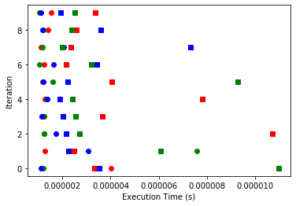

```python
from mySolution import timingTest1
timingTest1()
```

Using `timeit`, we can see how long it takes to run a snippet of code. We do 10 trials, calling both `get()` and `update()` 3 times per trial with 3 different elements. The circle points on the graph represent the times from the `get()` method, while the squares represent those from the `update()` method. A red mark indicates the time for the first element in the dict, green the middle element, and blue the final one.

The results of this test show that the running time `get()` and `update()` is not affected by the position of the element in the dict, and from this I draw the conclusion that these methods are O(1).

# Exercise 2

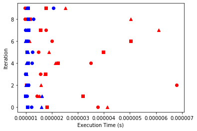

```python
from mySolution import timingTest2
timingTest2()
```

Similar to Exercise 1, we use `timeit` to determine the running time of the `del` operation on both a `dict` object (red) and a `list` object (blue). We run `del` on the first (circle), middle (square), and last (triangle) elements in both objects, and repeat this process 10 times to get a better understanding of the differences in execution time. It seems that the `del` operation on both objects is O(1), as the position of the element is shown to have no effect on running time. It also seems to be the case that execution time for `del` on a `dict` is on average longer than it is on a `list`, and that there is greater variation in the execution times for the `dict` than there is for the `list`.